# Example: data exploration

author: Aurélie Labbe, translation: Juliana Schulz

**We’ll now consider an example of an exploratory data analysis using R. It is important to remember that a thorough data exploration is a crucial step that should be done before carrying out any analysis; and in practice this important step is often neglected…**

The data that we’ll be exploring come from the website Kaggle and consist of the sale prices for 21,613 homes sold between May 2014 to May 2015 in King County in the state of Washington (which includes, among others, the city of Seattle). The data includes 19 variables measuring different characteristics of the homes, details on the variables are provided below:

- `id`: property identification number
- `date`: sale date
- `price`: sale price (variable of interest)
- `bedrooms`: number of rooms
- `bathrooms`: number of bathrooms
- `sqft_living`: home surface area (interior, measured in square feet)
- `sqft_lot`: lot surface area (entire property lot, measured in square feet)
- `floors`: number of floors
- `waterfront`: water view (1=yes, 0=no)
- `view`: number of views for the property in the real estate agency (note: no further explanation for this variable is provided)
- `condition`: condition of the property (rating from 1 to 5) as a function of the age and general state of the property (1=poor, 2=acceptable, 3=average, 4=good, 5=very good). This score is calculated according to the scoring system used in King county.
- `grade`: global score base on the quality of renovations and construction material (rating from 1 to 13 - a higher score indicates that the material used are of the highest quality). This score is calculated according to the scoring system used in King county.
- `sqft_above`: square footage of the property, excluding the basement
- `sqft_basement`: square footage of the basement
- `yr_built`: year of construction
- `yr_renovated`: year last renovated
- `zip`: postal code
- `lat`: latitude
- `long`: longitude

The following code allows to read the dataset:

```r
mydata=read.csv("Data/kc_house_data.csv")
dim(mydata)
```

```
## [1] 21613    21
```

```r
head(mydata)
```

```
##           id            date   price bedrooms bathrooms sqft_living sqft_lot
## 1 7129300520 20141013T000000  221900        3      1.00        1180     5650
## 2 6414100192 20141209T000000  538000        3      2.25        2570     7242
## 3 5631500400 20150225T000000  180000        2      1.00         770    10000
## 4 2487200875 20141209T000000  604000        4      3.00        1960     5000
## 5 1954400510 20150218T000000  510000        3      2.00        1680     8080
## 6 7237550310 20140512T000000 1225000        4      4.50        5420   101930
##   floors waterfront view condition grade sqft_above sqft_basement yr_built
## 1      1          0    0         3     7       1180             0     1955
## 2      2          0    0         3     7       2170           400     1951
## 3      1          0    0         3     6        770             0     1933
## 4      1          0    0         5     7       1050           910     1965
## 5      1          0    0         3     8       1680             0     1987
## 6      1          0    0         3    11       3890          1530     2001
##   yr_renovated zipcode     lat     long sqft_living15 sqft_lot15
## 1            0   98178 47.5112 -122.257          1340       5650
## 2         1991   98125 47.7210 -122.319          1690       7639
## 3            0   98028 47.7379 -122.233          2720       8062
## 4            0   98136 47.5208 -122.393          1360       5000
## 5            0   98074 47.6168 -122.045          1800       7503
## 6            0   98053 47.6561 -122.005          4760     101930
```

## Exploring the data: one variable at a time

We can begin by considering numerical summaries of each variable in order to identify missing values, outliers (looking at the min and max) and to quickly evaluate their distributions by looking at the quartiles. This can be done using the `summary` function, as shown in the following example:

```r
summary(mydata$price)
```

```
##    Min. 1st Qu.  Median    Mean 3rd Qu.    Max.
##   75000  321950  450000  540088  645000 7700000
```

**Exercise**: using the `summary` function, evluate the quantitative variables in the data. Does anything catch your attention? Are there any outlier or extreme observations?

Histograms and boxplots provide graphical summaries of numerical data, and provide a nice way of visualizing the distribution of quantitative variables. For certain statistical analyses, an underlying key assumption is normality of the variable in question. These graphical summaries allow to assess normality and the symmetry of variables.

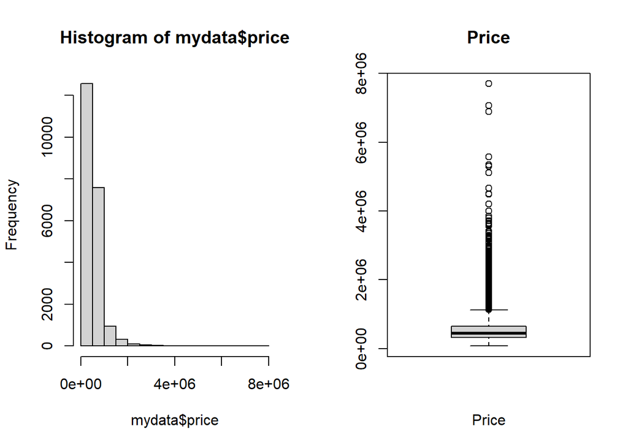

```r
# VPrice variable
par(mfrow=c(1,2))
hist(mydata$price)
boxplot(mydata$price,horizontal=F,main="Price",xlab="Price")
```

In the above example, we can see that the distribution of the `price` variable is skewed to the right. If we wish to use a linear regression to model the price of houses (which assumes normality), a `log` transformation would probably be necessary:

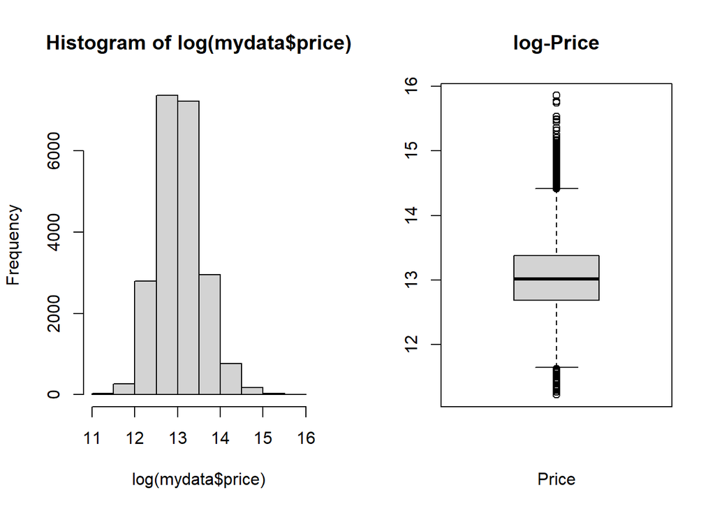

```r
# Variable price
par(mfrow=c(1,2))
hist(log(mydata$price))
boxplot(log(mydata$price),horizontal=F,main="log-Price",xlab="Price")
```

Understanding and exploring data requires a more thorough examination of certain variables in order to have a clearer idea of the profile of the data. For example, you should be able to answer basic questions regarding the data, in our example this could be, e.g., knowing the number of houses by price level. Here is some code that could help answer such a question:

```r
sum(price>2000000)
```

```
## [1] 198
```

```r
sum(price>3000000)
```

```
## [1] 45
```

```r
sum(price>4000000)
```

```
## [1] 11
```

The distribution of discrete (numerical) and categorical variables, such as the number of rooms, number of bathrooms, etc., could be illustrated using the `table` function, e.g.:

```r
table(bedrooms)
```

```
## bedrooms
##    0    1    2    3    4    5    6    7    8    9   10   11   33
##   13  199 2760 9824 6882 1601  272   38   13    6    3    1    1
```

**Exercise**: using the `table` function, examine the discrete / categorical variables. Are there any interesting findings?

**Exercise**: How many different postal codes are there?

**Exercise**: it’s always important to do little spot checks with data (be curious, and creative!). For example, is the sum of square footage of the property (excl. basement) and the square footage of the basement equal to the total living square footage? You could also check whether houses for which `sqft_living > sqft_lot` are indeed houses with several floors, etc…

## Exploring data: crossed variables

When using a linear regression model to explain or predict a variable of interest $Y$, it’s important to verify whether the relationship between $Y$ and each predictor $X_i$ is indeed linear. If we fit a linear regression model to data exhibiting a qudratic or log-linear relation, for example, the quality of the linear model (and predictions there from) could be greatly affected. It is therefore important to first look at what kind of relation (linear, quadratic, log…) seems to exist between each of the predictors and the response variable of interest. The following code shows a series of commands that will allow to evaluate the relationship between the price of the houses and the house characteristics. Feel free to remove the extreme values from your graphs (not from the data set!) to get a better view/idea of the relations. You can also look at the relation with the logarithm of the variables, for example, to further explore which transformation gives the best linear relationship between the variables.

Here is an example of some code for the variable `bedrooms`:

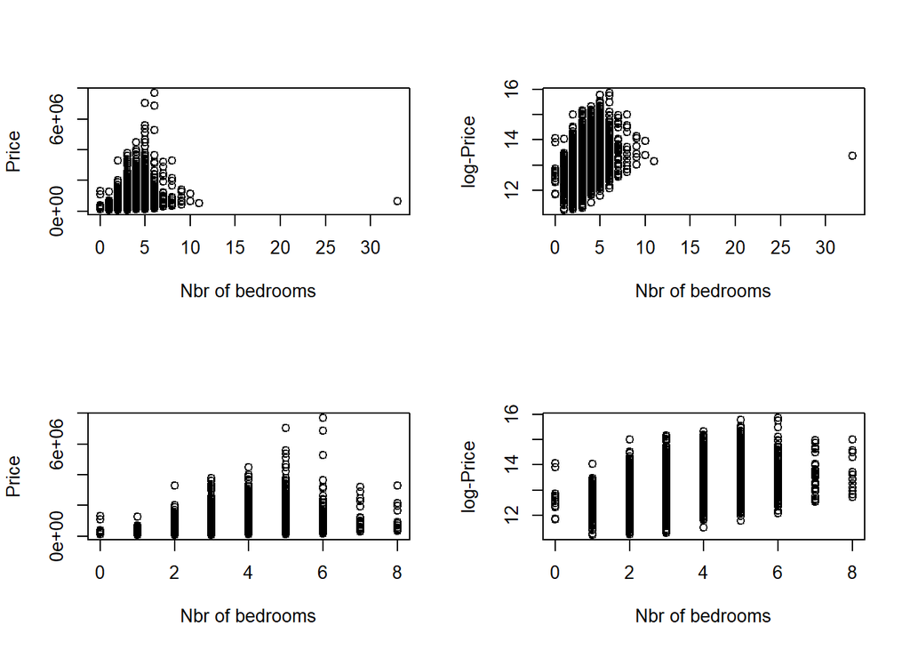

```r
# Bedrooms
par(mfrow=c(2,2))
plot(bedrooms,price,xlab="Nbr of bedrooms",ylab="Price")
plot(bedrooms,log(price),xlab="Nbr of bedrooms",ylab="log-Price")
plot(bedrooms[bedrooms<9],price[bedrooms<9],xlab="Nbr of bedrooms",ylab="Price")
plot(bedrooms[bedrooms<9],log(price[bedrooms<9]),xlab="Nbr of bedrooms",ylab="log-Price")
```

**Exercise**: Repeat the above with the other explanatory variables. What trends do you see?

## Exploring data: ggplot

The `ggplot2` library allows to produce more complex and higher quality graphics than the basic `plot` function in R. A gallery of graphics produced with ggplot can be found here: http://www.r-graph-gallery.com/portfolio/ggplot2-package/.

We won’t do a comprehensive introduction to `ggplot2` (this would be much too long, there are entire books on the subject), but we’ll go over some examples of useful graphs for visualizing data using `ggplot2`. The `ggplot2` syntax is different from more classic R functions and thus requires a bit of adaptation. In `ggplot2`, a graph consists of a succession of commands separate by the `+` symbol.

Before starting, make sure you have installed the `ggplot2` and `ggridges` libraries.

We’ll start by creating a histogram and a boxplot for the `price` variable. The `ggplot` function allows you to define the frame of the basic graph and to define which variables will be included. On its own, this function doesn’t do much, as the following code demonstrates:

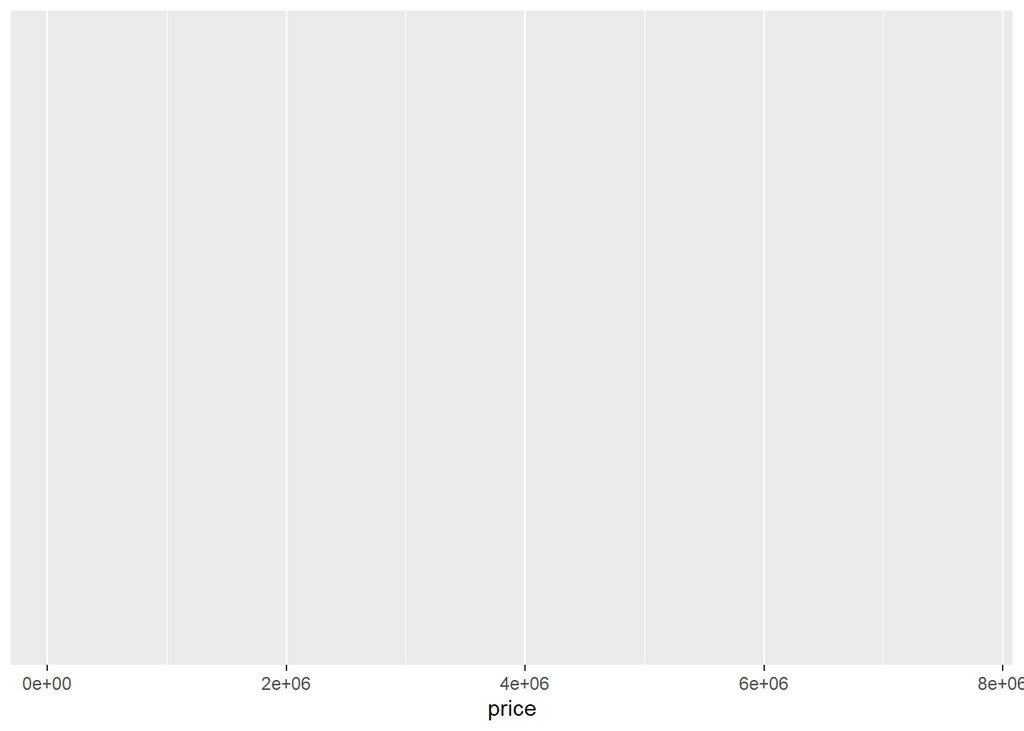

```r
library(ggplot2)
ggplot(mydata, aes(x=price))
```

By combining the base `ggplot` with other specific functions, many different types of graphs can be produced, such as the following histogram:

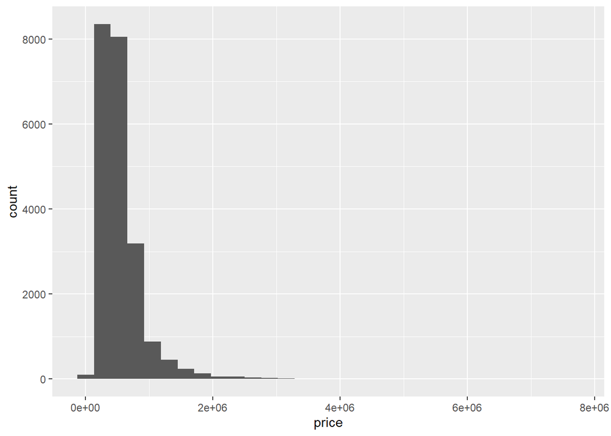

```r
ggplot(mydata, aes(x=price)) + geom_histogram()
```

It is possible to control the number of bins in the histogram with the `binwidth` option. It is also possible to add a title to the graph with the command `ggtitle`. The following code shows how to make 4 graphs in the same window (here on the log scale), one graph corresponding to one bin width:

```r
mydata$logprice=log(mydata$price)
head(mydata$logprice)
```

```
## [1] 12.30998 13.19561 12.10071 13.31133 13.14217 14.01845
```

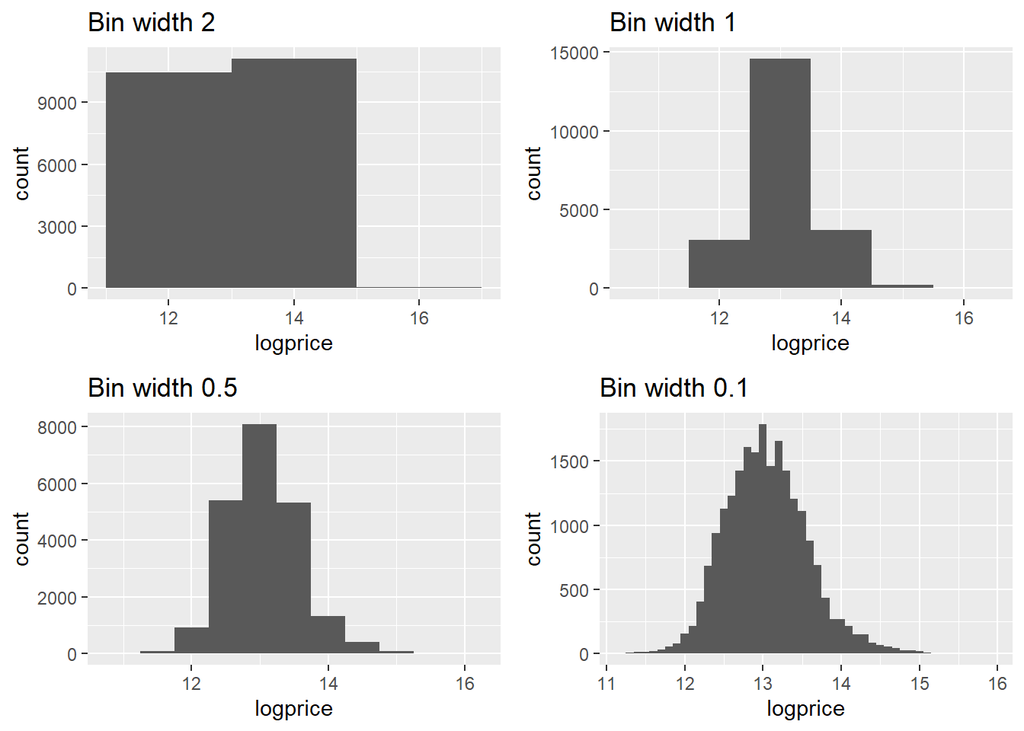

```r
plot1=ggplot(mydata, aes(x=logprice)) + geom_histogram(binwidth=2) + ggtitle("Bin width 2")
plot2=ggplot(mydata, aes(x=logprice)) + geom_histogram(binwidth=1) + ggtitle("Bin width 1")
plot3=ggplot(mydata, aes(x=logprice)) + geom_histogram(binwidth=0.5) + ggtitle("Bin width 0.5")
plot4=ggplot(mydata, aes(x=logprice)) + geom_histogram(binwidth=0.1) + ggtitle("Bin width 0.1")

gridExtra::grid.arrange(plot1, plot2, plot3, plot4, ncol = 2)
```

The following code shows how to create a boxplot of the variable `logprice`. There are several style and color options, here are 2 examples:

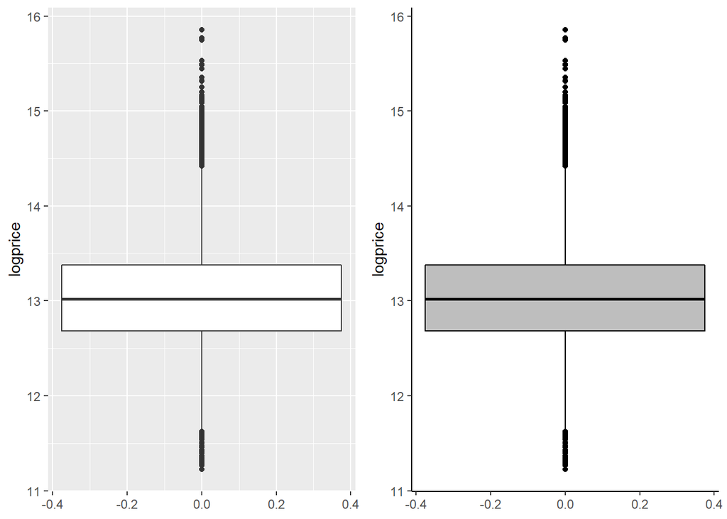

```r
plot1=ggplot(mydata, aes(y=logprice)) + geom_boxplot()
plot2=ggplot(mydata, aes(y=logprice)) + geom_boxplot(fill="gray", color="black")+ theme_classic()

gridExtra::grid.arrange(plot1, plot2, ncol = 2)
```

We can also make a boxplot of the variable `logprice` as a function of the number of floors in the house, for example. Note that this requires that the variable `floors` be converted to a factor variable Different options are shown below.

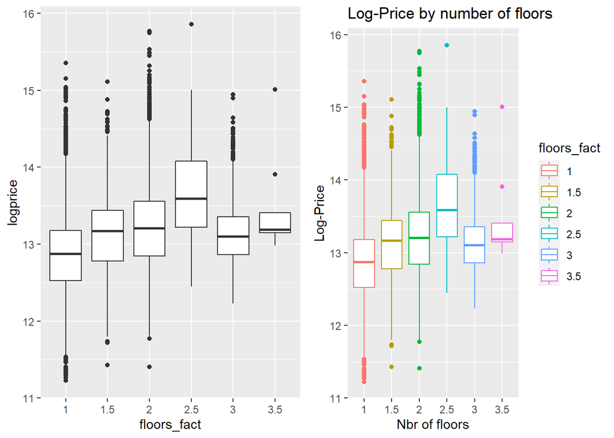

```r
mydata$floors_fact=as.factor(mydata$floors)
plot1=ggplot(mydata, aes(x=floors_fact,y=logprice)) + geom_boxplot()
plot2=ggplot(mydata, aes(x=floors_fact,y=logprice,color=floors_fact))  + geom_boxplot()+ labs(title="Log-Price by number of floors",x="Nbr of floors", y = "Log-Price")

gridExtra::grid.arrange(plot1, plot2, ncol = 2)
```

We can also look at how house prices (log scale) vary with the number of bedrooms for example:

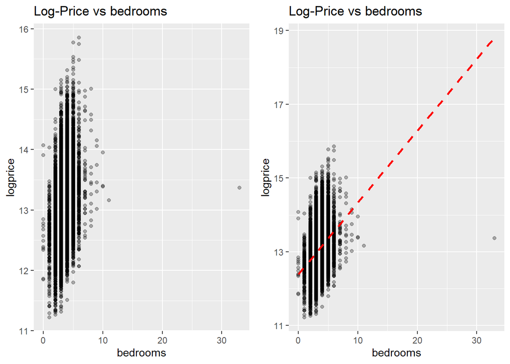

```r
plot1=ggplot(mydata,aes(x=bedrooms,y=logprice))+ geom_point(alpha = .3) + ggtitle("Log-Price vs bedrooms")

plot2=ggplot(mydata,aes(x=bedrooms,y=logprice))+ geom_point(alpha = .3) + ggtitle("Log-Price vs bedrooms") +  geom_smooth(method = "lm", se = FALSE, color = "red", lty = "dashed")

gridExtra::grid.arrange(plot1, plot2, ncol = 2)
```

Here is a last example of a more sophisticated graph, which requires loading the `ggridge` library. This graph allows to see the distribution of the price of the houses according to the condition.

```r
library(ggridges)
```

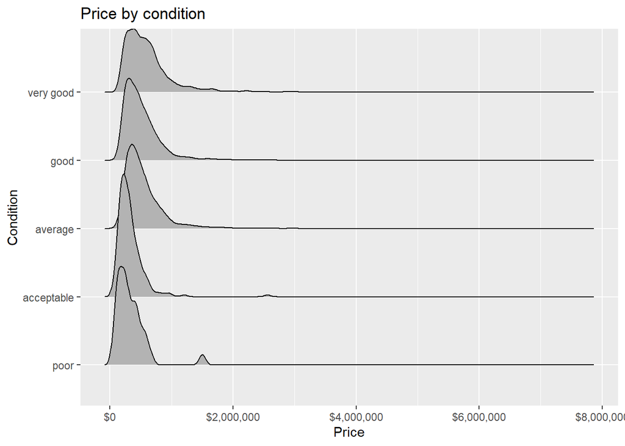

```r
mydata$fcondition=factor(mydata$condition,labels=c("poor", "acceptable", "average", "good", "very good"))
ggplot(mydata, aes(x = price, y = fcondition)) + ggridges::geom_density_ridges() + scale_x_continuous(labels= scales::dollar)+ labs(title="Price by condition",x="Price", y = "Condition")
```

### References

The possibilities with ggplot are extremely numerous. If you want to explore the subject in more detail, the following book is a great reference and is available online “ggplot2: elegant graphics for data analysis”, available at https://ggplot2-book.org